# Theory of Computation

Reagan Shirk

September 17, 2019

# Housekeeping

- Second homework will be posted today or tomorrow (17th or 18th) and will be due on 24th, 25th, or 26th. Should have grades posted by the 30th.
- October 1st will be discussion on homework problems, October 8th will be the first midterm

# What do we really mean by closure?

- We have regular languages such as $\left\{0, 1\right\}$ and something else that I can’t even read from the third row
- Regular languages lie inside of context-free languages
  - Context-free languages such as $L = \left\{0^n1^n | n \geq 0\right\}$
- Context-free languages lie within turing-decidable languages
  - Turing-decidable languages such as $L = \left\{0^n1^n2^n | n \geq 0\right\}$
  - This is the limit of the kinds of machines we are capable of developing
- Turing decidable languages lie within turing recognizable languages such as $A_{tm}$ (halting problem) or hilberts 10th problem
  - Halting problem says that if you have a computer and you give it a set of problems/input to that computer, is there something that can tell you if the computer will output, error, hold, etc
  - Hilberts 10th problem asks about solutions on polynomial equations
  - Languages for which we can construct some kind of machine that only accepts “yes” instances - no way of doing it if it accepts the “no” instances
- Turing decidable languages lie within undecidable languages
  - I’m unbelievably lost right now
- Somehow this tells us why closure is important…?

# Regular Expressions

- $\left(0 \cup 1\right)0^*$ (the book uses $+$ instead of $\cup$)
  - Order of operations: like regular math, exponent, product, sum

# Definition of Regular Expression

- We say that $R$ is a regular expression if $R$ is:
  - $a$, for some $a$ in $\Sigma$
  - $\lambda$
  - $\left\{\right\}$
  - $\left(R_1 + R_2\right)$ where $R_1$ and $R_2$ are regular expressions
  - $\left(R_1 \circ R_2\right)$ where $R_1$ and $R_2$ are regular expressions
  - $R_1^*$ where $R_1$ is a regular expression
- Also have notation $R^+$, not sure if that’s part of the above criteria
  - $R^+ = R(R^*)$
  - $R^+ \cup \left\{lambda\right\}$ gives $R^*$, idk why

# Identities for Regular Expressions

- $R + \varnothing = R$
- $R \circ \lambda = R$
- In principle, $R + \lambda \neq R$ because $R$ may or may not already include $\lambda$
  - For example, $R = 0$, then $L(R) = \left\{0\right\}$. Then $R + \lambda = \left\{0, \lambda\right\}$
- $R \circ \left\{\right\} \neq R$

# Equivalence with Finite Automata

- Theorem: A language is regular iff a regular expression describes the language
- Lemma (proof of theorem): if a language is described by a regular expression, then it is regular
- Proof idea (also lemma?): Decompose the regular expression (regex) $R$ into smaller pieces and then put those pieces together
  - Case 1: $R = a$. NFA: Initial state with a go to accepting state
  - Case 2: $R = \lambda$. NFA: Initial state is accepting state
  - Case 3: $R = \left\{\right\}$. NFA: One state, starting state. No accepting state
  - Case 4: $R_1 + R_2$. NFA: Follow from closure of the operation
  - Case 5: $R_1 \circ R_2$. NFA: Follow from closure of the operation
  - Case 6: $R_1^*$. NFA: Follow from the closure of the operation

# Examples

- Convert the regex $\left(ab+a\right)^*$ to an NFA in a sequence of stages

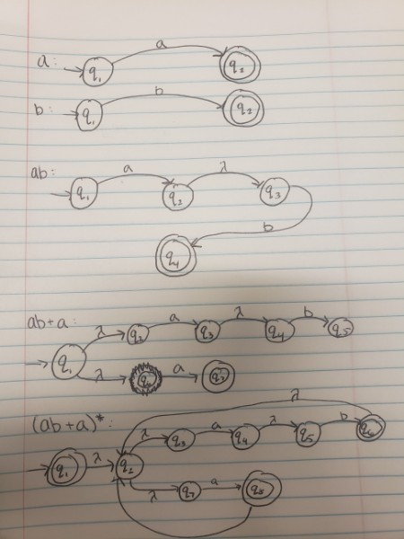

State Diagram

- Convert the regex $R + \left(a+b\right)^*aba$ into an NFA

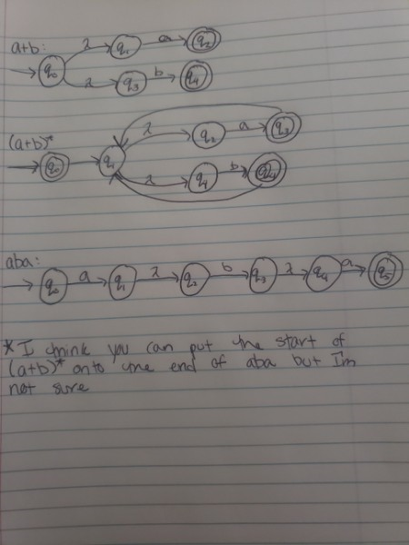

State Diagram